# F2 simulations results

This report include analysis with all output files generated by the simulations workflow for F2 populations.

## Output files

Short description about the output files.

From pedsim_files task:

- mapfile.map

marker chromosome position(cM)

- tot_mks.txt

chr pos ref alt

From aval_vcf task:

- method_alt_depth.txt

method = c(“gatk”, “freebayes”, “stacks”)

columns = individuals lines = markers cells = counts for alternative alleles

- method_ref_depth.txt

method = c(“gatk”, “freebayes”, “stacks”)

columns = individuals lines = markers cells = counts for reference alleles

- method_GQ.txt

Ta com pau.. arrumar!

- method.txt nmk.filt nmk.id ok falso.positivo ref.ok alt.ok

From all_maps task:

- method_error_info_genotypeMethod.txt

method = c(“gatk”, “freebayes”, “stacks”) genotypeMethod = c(“GQ”, “polyrad”, “supermassa”, “updog”)

MK POS gabGT methGT 1 2 3 4 5

- method_filters_genotypeMethod.txt

method = c(“gatk”, “freebayes”, “stacks”) genotypeMethod = c(“dfAndGQ”, “polyrad”, “supermassa”, “updog”)

n_markers distorted_markers redundant_markers

- method_map_genotypeMethod.txt

method = c(“gatk”, “freebayes”, “stacks”) genotypeMethod = c(“df”, “GQ”, “polyrad”, “supermassa”, “updog”)

MK POS cM

# Path

**The only part of this report that you need to change**

```r
path <- "~/github/errors_workflow/cromwell-executions/F2/0053b719-69f8-466c-b3f0-861f5a7c35d1/"
cMByMb <- 4.63
```

# Packages

```r
library(ggplot2)
library(reshape2)
library(vcfR)
```

# Code for only one family - pilot

```r
setwd(path)
method <- c("gatk", "freebayes")
meth.geno <- c("GQ", "polyrad", "updog", "supermassa")

mapfile <- read.table("call-pedsim_files/execution/mapfile.map", header=T)

tot_mks <- read.table("call-pedsim_files/execution/tot_mks.txt")
id <- c(0,1)
p  <- list()


df.diff.dis <- as.list(rep(NA, length(method)))
for(i in 1:length(df.diff.dis)){
  df.diff.dis[[i]] <- as.list(rep(NA, length(meth.geno)))
}

df.per.geno <- df.coverage <- df.diff.tot <- df.diff.median <- df.diff.mean <- names.id <- vector()

for(i in 1:length(method)){
  ## vcfs
  vcf <- read.vcfR(paste0("call-vcftools_filter/execution/",method[i], ".recode.vcf"))
  gt <- vcf@gt[,-1]
  gt <- melt(gt)
  gt$value <- sapply(strsplit(as.character(gt$value), ":"), "[", 1)

  ## Depths
  alt_depth <- read.table(paste0("call-aval_vcf/execution/", method[i], "_alt_depth.txt"), header = T, stringsAsFactors = F)
  alt_depth <- as.data.frame(apply(alt_depth, 2, as.integer))
  alt <- melt(alt_depth)

  ref_depth <- read.table(paste0("call-aval_vcf/execution/", method[i], "_ref_depth.txt"), header = T, stringsAsFactors = F)
  ref_depth <- as.data.frame(apply(ref_depth, 2, as.integer))
  ref <- melt(ref_depth)
  df.depths <- data.frame(ind = gt$Var2, gt = gt$value, alt = alt$value, ref=ref$value)

  p[[i]] <- ggplot(df.depths, aes(x=ref, y=alt, color=as.factor(gt))) + geom_point(size=0.5) +
    labs(title= paste0(method[i]," depths example"),x="ref", y = "alt", color="Genotypes")

  for(j in 1:length(meth.geno)){
    # Map distance
    maps <- read.table(paste0("call-all_maps/shard-", id[i],"/execution/", method[i],"_map_", meth.geno[j],".txt"), header =T)

    poscM <- (as.numeric(as.character(maps[,2]))/1000000)*cMByMb
    poscM.norm <- poscM-poscM[1]
    maps <- cbind(maps, poscM, poscM.norm)

    # Difference between distances real and estimated
    diff.dis <- sqrt((maps$poscM.norm - maps$rf)^2)
    df.diff.dis[[i]][[j]] <- diff.dis
    names(df.diff.dis[[i]][[j]]) <- paste0(method[i],"_",meth.geno[j])

    # Meth names
    names.id <-  c(names.id,paste0(method[i],"_",meth.geno[j]))

    # Mean of differences
    diff.dis.mean <- mean(sqrt((maps$poscM.norm - maps$rf)^2))
    df.diff.mean <- c(df.diff.mean,diff.dis.mean)


    # Median of differences
    diff.dis.median <- median(sqrt((maps$poscM.norm - maps$rf)^2))
    df.diff.median <- c(df.diff.median,diff.dis.median)

    # Difference of total size
    diff.tot.dis <- sqrt((maps$poscM.norm[length(maps$poscM.norm)] - maps$rf[length(maps$rf)])^2)
    df.diff.tot <- c(df.diff.tot,diff.tot.dis)

    mapfile.pos <- cbind(mapfile, tot_mks[,2])

    # Percentage of the chromosome covered
    coverage <- maps$pos[length(maps$pos)]*100/mapfile.pos[,4][length(mapfile.pos[,4])]
    df.coverage <- c(df.coverage,coverage)

    # Percentage of rigth genotyping
    per.geno <- read.table(paste0("call-all_maps/shard-",id[i],"/execution/",method[i],"_error_info_",meth.geno[j],".txt"), header =T)
    per.geno <- (sum(per.geno$gabGT == per.geno$methGT)/length(per.geno$methGT)*100)
    df.per.geno <- c(df.per.geno,per.geno)

  }
}
```

## Depth

Aqui mostra a distribuição das contagens de cada alelo, teoricamente deveriam ter homozigotos para os dois pais e heterozigotos no meio, uma diagonal (mas parece que só esta simulando homozigotos, isso altera tudo em seguida).

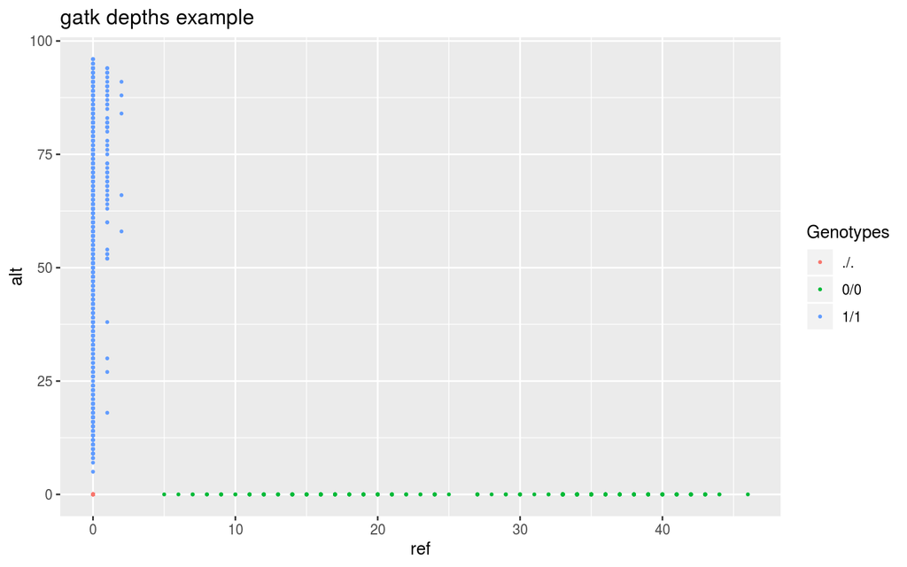

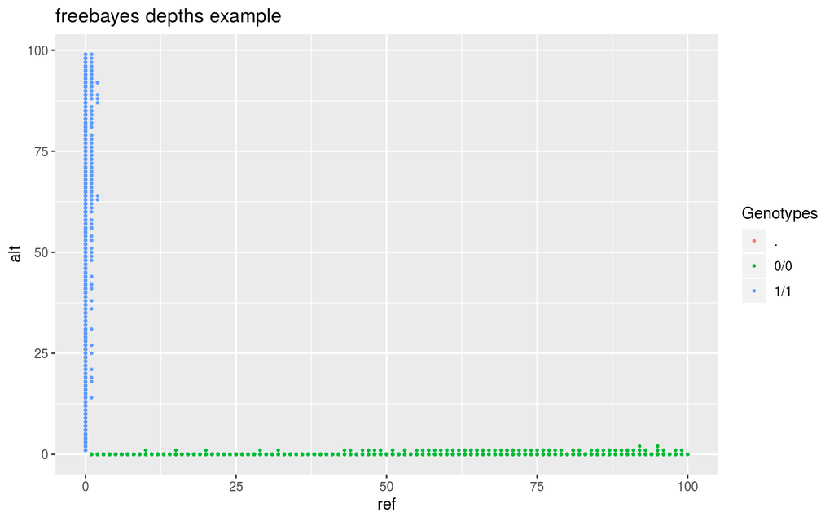

```r
# Depths
p
```

## Difference between distances real and estimated

As distâncias estimadas do mapa deveriam ser as mesmas das simuladas, quanto mais perto do 0 o valor, melhor. O primeiro número sempre vai ser 0 porque eu normalizei.

```r
df.diff.dis
```

```
## [[1]]
## [[1]][[1]]
##    gatk_GQ       <NA>       <NA>       <NA>       <NA>       <NA>
## 0.00000000 0.00191608 0.11378077 0.18746648 0.19459131 0.23436227
##       <NA>       <NA>       <NA>       <NA>       <NA>       <NA>
## 0.26879021 0.30725551 0.42274549 0.61126446 0.79345422 0.89528570
##       <NA>       <NA>       <NA>       <NA>       <NA>       <NA>
## 0.89647950 0.92080941 0.95963122 0.98746604 0.99472977 1.04157074
##       <NA>       <NA>       <NA>       <NA>       <NA>       <NA>
## 1.18004404 1.20272567 1.20953103 1.28686518 1.29314272 1.45371501
##       <NA>       <NA>       <NA>       <NA>       <NA>       <NA>
## 1.50348214 1.59853993 1.70540885 1.72561806 1.74503091 1.85834479
##       <NA>       <NA>       <NA>       <NA>       <NA>       <NA>
## 1.99425307 2.14926010 2.39071849 2.41409462 2.41464022 2.41638499
##       <NA>       <NA>       <NA>       <NA>       <NA>       <NA>
## 2.43196883 2.49099882 2.50483538 2.57079648 2.63435460 2.64096836
##       <NA>       <NA>       <NA>
## 2.71672190 2.73472083 2.76777189
##
## [[1]][[2]]
## gatk_polyrad         <NA>         <NA>         <NA>         <NA>
##    0.0000000    0.8998337    0.7879690    0.7142833    0.7071585
##         <NA>         <NA>         <NA>         <NA>         <NA>
##    1.6357301    1.6013022    1.5628369    1.4473469    1.2592420
##         <NA>         <NA>         <NA>         <NA>         <NA>
##    4.5294567    8.9589690    8.9577752    8.9334453    8.8946235
##         <NA>         <NA>         <NA>         <NA>         <NA>
##    8.8667886    8.8595249    8.8126839    8.6742106    8.6515290
##         <NA>         <NA>         <NA>         <NA>         <NA>
##    8.6447236    8.5673895    8.5611120    8.4005397    8.3507725
##         <NA>         <NA>         <NA>         <NA>         <NA>
##    8.2557147    9.1913594    9.1711502    9.1517373    9.0384235
##         <NA>         <NA>         <NA>         <NA>         <NA>
##    8.9025152    9.8434972    9.6020388    9.5786627    9.5781171
##         <NA>         <NA>         <NA>         <NA>         <NA>
##    9.5763723    9.5607885   10.4002803   10.3864420   10.3204791
##         <NA>         <NA>         <NA>         <NA>         <NA>
##   10.2569192   10.2503037   10.1745484   10.1565477   10.1234949
##
## [[1]][[3]]
```

[output cut: 195 more lines]

```
##                 <NA>                 <NA>                 <NA>
##           2.92448565           2.92453584           3.01703787
##                 <NA>                 <NA>                 <NA>
##           3.14135726           3.17309980           3.44620424
##                 <NA>                 <NA>                 <NA>
##           3.61186953           3.71313615           3.71510316
##                 <NA>                 <NA>                 <NA>
##           3.85788699           3.90520368           3.95778006
##                 <NA>                 <NA>                 <NA>
##           3.97127923           4.01114162           4.05467561
##                 <NA>                 <NA>                 <NA>
##           4.08106470           4.15584655           4.16492871
##                 <NA>                 <NA>                 <NA>
##           4.24395151           4.25444106           4.26974130
##  [ reached getOption("max.print") -- omitted 46 entries ]
```

## Difference of total size

Como serão várias famílias, vai ficar difícil comparar em relação à todas as marcas, então estou considerando comparar só o tamanho total, média e mediana de cada família

```r
rbind(names.id,df.diff.tot)
```

```
##             [,1]               [,2]               [,3]
## names.id    "gatk_GQ"          "gatk_polyrad"     "gatk_updog"
## df.diff.tot "2.76777188608869" "10.1234948601576" "12.1833634032808"
##             [,4]               [,5]               [,6]
## names.id    "gatk_supermassa"  "freebayes_GQ"     "freebayes_polyrad"
## df.diff.tot "2.76777189604819" "25.5811558090347" "3868.08489587108"
##             [,7]               [,8]
## names.id    "freebayes_updog"  "freebayes_supermassa"
## df.diff.tot "11.4209558627519" "3.53215353801372"
```

## Median of differences

```r
rbind(names.id,df.diff.median)
```

```
##                [,1]               [,2]               [,3]
## names.id       "gatk_GQ"          "gatk_polyrad"     "gatk_updog"
## df.diff.median "1.29314271997799" "8.89462345285766" "0.492948604992998"
##                [,4]               [,5]               [,6]
## names.id       "gatk_supermassa"  "freebayes_GQ"     "freebayes_polyrad"
## df.diff.median "1.29314271997799" "3.52902688493948" "11.3534126416928"
##                [,7]               [,8]
## names.id       "freebayes_updog"  "freebayes_supermassa"
## df.diff.median "2.52331035746962" "2.57075178995599"
```

## Mean of differences

```r
rbind(names.id,df.diff.mean)
```

```
##              [,1]               [,2]              [,3]
## names.id     "gatk_GQ"          "gatk_polyrad"    "gatk_updog"
## df.diff.mean "1.44147857940047" "7.3510808633069" "1.7570096213106"
##              [,4]               [,5]               [,6]
## names.id     "gatk_supermassa"  "freebayes_GQ"     "freebayes_polyrad"
## df.diff.mean "1.44147858023311" "11.2949779514328" "440.770159316857"
##              [,7]               [,8]
## names.id     "freebayes_updog"  "freebayes_supermassa"
## df.diff.mean "2.88718838602851" "2.59667068576262"
```

## Percentage of rigth genotyping

Comparação entre os genótipos simulados e estimados com cada método

```r
rbind(names.id,df.per.geno)
```

```
##             [,1]               [,2]               [,3]
## names.id    "gatk_GQ"          "gatk_polyrad"     "gatk_updog"
## df.per.geno "44.3498817966903" "57.3049645390071" "43.8196555217832"
##             [,4]               [,5]               [,6]
## names.id    "gatk_supermassa"  "freebayes_GQ"     "freebayes_polyrad"
## df.per.geno "44.3498817966903" "39.5884199511685" "55.1950354609929"
##             [,7]               [,8]
## names.id    "freebayes_updog"  "freebayes_supermassa"
## df.per.geno "39.3990294886152" "39.5990856339019"
```

## Percentage of the chromosome covered

Aqui esta outro problema, ele esta simulando somente para parte do genoma

```r
rbind(names.id,df.coverage)
```

```
##             [,1]               [,2]               [,3]
## names.id    "gatk_GQ"          "gatk_polyrad"     "gatk_updog"
## df.coverage "2.59639227239816" "2.59639227239816" "2.59639227239816"
##             [,4]               [,5]               [,6]
## names.id    "gatk_supermassa"  "freebayes_GQ"     "freebayes_polyrad"
## df.coverage "2.59639227239816" "6.31198058903585" "6.22517059703987"
##             [,7]               [,8]
## names.id    "freebayes_updog"  "freebayes_supermassa"
## df.coverage "6.31198058903585" "6.31198058903585"
```

```
Só para lembrar:
Acho que rola fazer uma discussão sobre numero de indivíduos e resolução do mapa, com poucos individuos o mapa fica inflado tb

Rola fazer outra discussão sobre a cobertura que o RADseq cobre , a capacidade dos softwares de identificar no genoma inteiro - Se o tamanho total do mapa nao corresponder ao cromossomo inteiro pode ser que ele esteja inflado e as pessoas pensem que ele esta no tamanho certo
```

[Statistical Genetics Lab](http://statgen.esalq.usp.br)  
Department of Genetics  
Luiz de Queiroz College of Agriculture  
University of São Paulo

2019-07-22